# HW12_94104778

```r
ratings = fread('~/Downloads/ml/ratings.dat', sep = ':')[, c(1, 3, 5, 7), with = FALSE]
```

```
##
Read 47.2% of 10000054 rows
Read 95.9% of 10000054 rows
Read 10000054 rows and 7 (of 7) columns from 0.247 GB file in 00:00:04
```

```r
setnames(ratings, c('UserID', 'MovieID', 'Rating', 'Timestamp'))
ratings = ratings %>% mutate(rateYear = as.integer(Timestamp / 31536000) + 1970)
tags = fread('~/Downloads/ml/tags1.dat', sep = ':')[, c(1, 3, 5, 7), with = FALSE]
setnames(tags, c('UserID', 'MovieID', 'Tag', 'Timestamp'))
movies = fread('~/Downloads/ml/movies1.dat', sep = ':')[, c(1, 3, 5), with = FALSE]
setnames(movies, c('MovieID', 'Title', 'Genres'))
```

## Q1

```r
##The movie with the most number of ratings == 0.5
ratings %>% filter(Rating == 5.0) %>% group_by(MovieID) %>% summarise(n = n()) %>% arrange(desc(n)) %>% top_n(1) %>% inner_join(movies, by = "MovieID") %>% select(Title)
```

```
## # A tibble: 1 x 1
##   Title
##   <chr>
## 1 Shawshank Redemption, The (1994)
```

```r
tags %>% group_by(MovieID) %>% summarise(n = n()) %>% arrange(desc(n)) %>% top_n(1) %>% inner_join(movies, by = "MovieID") %>% select(Title)
```

```
## # A tibble: 1 x 1
##   Title
##   <chr>
## 1 Pulp Fiction (1994)
```

```r
##The movie with the most number of ratings == 0.1
ratings %>% filter(Rating == 1.0) %>% group_by(MovieID) %>% summarise(n = n()) %>% arrange(desc(n)) %>% top_n(1) %>% inner_join(movies, by = "MovieID") %>% select(Title)
```

```
## # A tibble: 1 x 1
##   Title
##   <chr>
## 1 Dumb & Dumber (1994)
```

```r
movies$Year = unlist(str_extract_all(movies$Title,"[(][0-9]{4}[)]"))
movies %>% group_by(Year) %>% summarise(n = n())
```

```
## # A tibble: 94 x 2
##    Year       n
##    <chr>  <int>
##  1 (1915)     1
##  2 (1916)     2
##  3 (1917)     2
##  4 (1918)     2
##  5 (1919)     4
##  6 (1920)     5
##  7 (1921)     3
##  8 (1922)     7
##  9 (1923)     6
## 10 (1924)     6
## # ... with 84 more rows
```

```r
##Genres with the maximum number of ratings above 4 in each year
genreRating <- movies %>% inner_join(ratings, by = "MovieID") %>% select(rateYear,Genres,Rating) %>% filter(Rating >= 4.0)  %>% group_by(rateYear,Genres) %>% summarise(n = n())
genreRating %>% group_by(rateYear) %>% arrange(desc(n)) %>% top_n(1)
```

```
## # A tibble: 15 x 3
## # Groups:   rateYear [15]
##    rateYear Genres                            n
##       <dbl> <chr>                         <int>
##  1     2000 Drama                         78279
##  2     1999 Drama                         49855
##  3     1996 Drama                         48543
##  4     2005 Drama                         46078
##  5     2001 Drama                         44118
##  6     2002 Drama                         30929
##  7     2003 Drama                         30825
##  8     2004 Drama                         29708
##  9     2008 Drama                         29112
## 10     2006 Drama                         28539
## 11     2007 Drama                         26565
## 12     1997 Drama                         22847
## 13     1998 Drama                         10746
## 14     2009 Drama                          1386
## 15     1995 Crime|Horror|Mystery|Thriller     1
```

## Q2

```r
##genres
genres <- str_split_fixed(movies$Genres, "[|]",n=Inf)
colnames(genres) <- c("V1","V2","V3","V4","V5","V6","V7","V8")
genres <- data.frame(genres)

##number per genres
G1 = genres %>% group_by(V1) %>% summarise(n = n())
G2 = genres %>% group_by(V2) %>% summarise(n = n())
colnames(G2) <- c("V1","n")
G3 = genres %>% group_by(V3) %>% summarise(n = n())
G4 = genres %>% group_by(V4) %>% summarise(n = n())
G5 = genres %>% group_by(V5) %>% summarise(n = n())
G6 = genres %>% group_by(V6) %>% summarise(n = n())
G7 = genres %>% group_by(V7) %>% summarise(n = n())
G8 = genres %>% group_by(V8) %>% summarise(n = n())
colnames(G3) <- c("V1","n")
colnames(G4) <- c("V1","n")
colnames(G5) <- c("V1","n")
colnames(G6) <- c("V1","n")
colnames(G7) <- c("V1","n")
colnames(G8) <- c("V1","n")
all <- rbind(rbind(rbind(rbind(rbind(rbind(rbind(G1,G2),G3),G4),G5),G6),G7),G8)
numberpergenres <- all %>% group_by(V1) %>% summarise(n = sum(n))
numberpergenres = numberpergenres[2:20,]
hchart(numberpergenres, "column", hcaes(x = V1, y = n))
```

[interactive chart not shown]

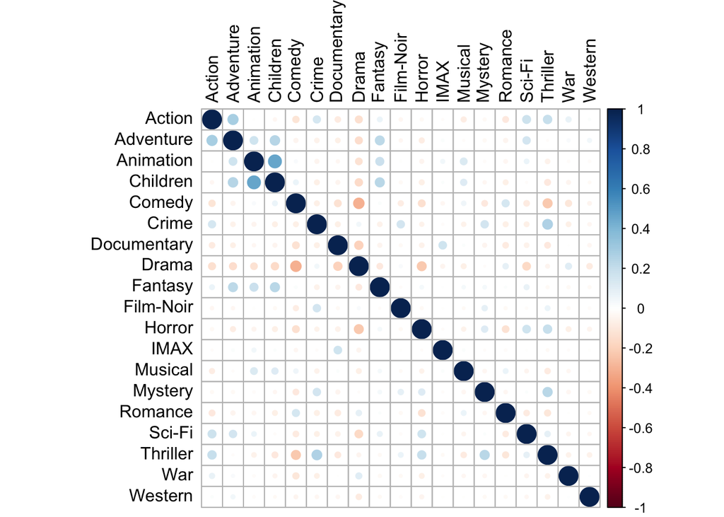

```r
##correlation Matrix for genres

movies %>% separate_rows(Genres, sep = "\\|") %>% filter(Genres != "(no genres listed)") -> movieGenres
Spread <- movieGenres %>% mutate(Genre = 1) %>% spread(Genres, Genre, fill = 0)
Spread <- as.matrix(Spread[4:22])
cor = cor(apply(Spread,2,as.numeric))
corrplot::corrplot(cor, tl.col = "black")
```

```r
##mean rate for each genre
genretotalmeanRate <- data.frame()
for (i in numberpergenres$V1){
  new <-movies %>% filter(grepl(i,Genres)) %>% inner_join(ratings,by="MovieID") %>% mutate(totalRate = mean(Rating,na.rm = T)) %>% select(totalRate) %>% head(1)
  new <- unlist(new)
  genretotalmeanRate <- rbind(genretotalmeanRate, new)
}
cbind(genretotalmeanRate,numberpergenres$V1[2:20])
```

```
##    X3.4213307400955 numberpergenres$V1[2:20]
## 1          3.421331                Adventure
## 2          3.493621                Animation
## 3          3.599988                 Children
## 4          3.418474                   Comedy
## 5          3.436946                    Crime
## 6          3.665655              Documentary
## 7          3.783459                    Drama
## 8          3.673263                  Fantasy
## 9          3.502019                Film-Noir
## 10         4.012151                   Horror
## 11         3.269243                     IMAX
## 12         3.764537                  Musical
## 13         3.562478                  Mystery
## 14         3.677631                  Romance
## 15         3.553776                   Sci-Fi
## 16         3.396193                 Thriller
## 17         3.507186                      War
## 18         3.780173                  Western
## 19         3.555657                     <NA>
```

```r
##Dorane talaei
DoranTalaei <- data.frame()
for (i in numberpergenres$V1){
  new <-movies %>% filter(grepl(i,Genres)) %>% group_by(Year) %>% summarise(n = n()) %>% arrange(desc(n)) %>% top_n(1)
  DoranTalaei <- rbind(DoranTalaei,new)
}
cbind(DoranTalaei,numberpergenres$V1[1:20])
```

```
##      Year   n numberpergenres$V1[1:20]
## 1  (2005)  69                   Action
## 2  (2005)  48                Adventure
## 3  (2006)  19                Animation
## 4  (1995)  30                 Children
## 5  (2000) 161                   Comedy
## 6  (2002)  56                    Crime
## 7  (2002)  42              Documentary
## 8  (2002) 248                    Drama
## 9  (2006)  34                  Fantasy
## 10 (1947)  14                Film-Noir
## 11 (1981)  40                   Horror
## 12 (1999)   4                     IMAX
## 13 (2002)  14                  Musical
## 14 (2003)  14                  Mystery
## 15 (2006)  29                  Romance
## 16 (2001)  80                   Sci-Fi
## 17 (2004)  28                 Thriller
## 18 (2007)  99                      War
## 19 (2007)  22                  Western
## 20 (1969)  11                     <NA>
```

## Q3

```r
stop_words = rbind(stop_words, c("a.k.a", "SMART"))
all_words = movies %>% unnest_tokens(word, Title)
all_words = all_words %>% anti_join(stop_words, by = 'word')
all_words = all_words %>% filter(!grepl('[0-9]+', word))
all_words %>% count(word, sort = TRUE) %>% wordcloud2(., size=1)
```

[interactive chart not shown]

## Q4

```r
moviesandusers <- movies %>% inner_join(ratings, by = "MovieID") %>% filter(Rating >=3) %>% group_by(UserID) %>% summarise(MovieNames = list(c(Title)))

transactions <- as(moviesandusers$MovieNames, "transactions")
rules <- apriori(transactions, parameter = list(support = 0.01,confidence = 0.25, minlen = 2))
```

```
## Apriori
##
## Parameter specification:
##  confidence minval smax arem  aval originalSupport maxtime support minlen
##        0.25    0.1    1 none FALSE            TRUE       5    0.01      2
##  maxlen target   ext
##      10  rules FALSE
##
## Algorithmic control:
##  filter tree heap memopt load sort verbose
##     0.1 TRUE TRUE  FALSE TRUE    2    TRUE
##
## Absolute minimum support count: 698
##
## set item appearances ...[0 item(s)] done [0.00s].
## set transactions ...[10597 item(s), 69863 transaction(s)] done [1.32s].
## sorting and recoding items ... [2136 item(s)] done [0.21s].
## creating transaction tree ... done [0.07s].
## checking subsets of size 1 2 3
```

```
##  done [77.98s].
## writing ... [38149222 rule(s)] done [7.78s].
## creating S4 object  ... done [9.31s].
```

```r
subsetCastle = subset(rules, lhs %in% c("Castle in the Sky (Tenkû no shiro Rapyuta) (1986)"))

subsetCastAway = subset(rules, lhs %in% c("Cast Away (2000)"))

subsetNocountry = subset(rules, lhs %in% c("No Country for Old Men (2007)"))

subsetMomento = subset(rules, lhs %in% c("Memento (2000)"))


inspect(sort(subsetCastle,by = "confidence")[1:5])
```

```
##     lhs                                                              rhs                                                              support confidence     lift count
## [1] {Castle in the Sky (Tenkû no shiro Rapyuta) (1986),
##      Lord of the Rings The Two Towers, The (2002)}                => {Lord of the Rings The Fellowship of the Ring, The (2001)}    0.01249588  0.9721604 4.603364   873
## [2] {Castle in the Sky (Tenkû no shiro Rapyuta) (1986),
##      Lord of the Rings The Return of the King, The (2003)}        => {Lord of the Rings The Fellowship of the Ring, The (2001)}    0.01228118  0.9662162 4.575218   858
## [3] {Castle in the Sky (Tenkû no shiro Rapyuta) (1986),
##      Star Wars Episode VI - Return of the Jedi (1983)}            => {Star Wars Episode V - The Empire Strikes Back (1980)}        0.01063510  0.9636835 3.062771   743
## [4] {Castle in the Sky (Tenkû no shiro Rapyuta) (1986),
##      Star Wars Episode VI - Return of the Jedi (1983)}            => {Star Wars Episode IV - A New Hope (a.k.a. Star Wars) (1977)} 0.01049196  0.9507134 2.455986   733
## [5] {Castle in the Sky (Tenkû no shiro Rapyuta) (1986),
##      Star Wars Episode IV - A New Hope (a.k.a. Star Wars) (1977)} => {Star Wars Episode V - The Empire Strikes Back (1980)}        0.01145098  0.9489917 3.016077   800
```

```r
inspect(sort(subsetCastAway,by = "confidence")[1:5])
```

```
##     lhs                                 rhs                        support confidence     lift count
## [1] {Cast Away (2000),
##      Matrix Revolutions, The (2003)} => {Matrix, The (1999)}    0.02222922  0.9779597 3.134235  1553
## [2] {Cast Away (2000),
##      Serenity (2005)}                => {Matrix, The (1999)}    0.01246726  0.9677778 3.101604   871
## [3] {Cast Away (2000),
##      Equilibrium (2002)}             => {Matrix, The (1999)}    0.01208079  0.9601820 3.077260   844
## [4] {Cast Away (2000),
##      Matrix Reloaded, The (2003)}    => {Matrix, The (1999)}    0.03458197  0.9545634 3.059253  2416
## [5] {Cast Away (2000),
##      Godfather Part II, The (1974)}  => {Godfather, The (1972)} 0.04116628  0.9538972 3.479461  2876
```

```r
inspect(sort(subsetNocountry,by = "confidence")[1:5])
```

```
##     lhs                                                     rhs                            support confidence     lift count
## [1] {Godfather Part II, The (1974),
##      No Country for Old Men (2007)}                      => {Godfather, The (1972)}     0.01624608  0.9904014 3.612615  1135
## [2] {Matrix Reloaded, The (2003),
##      No Country for Old Men (2007)}                      => {Matrix, The (1999)}        0.01263902  0.9876957 3.165438   883
## [3] {Back to the Future Part II (1989),
##      No Country for Old Men (2007)}                      => {Back to the Future (1985)} 0.01047765  0.9669749 3.397323   732
## [4] {Back to the Future Part II (1989),
##      No Country for Old Men (2007)}                      => {Matrix, The (1999)}        0.01040608  0.9603699 3.077862   727
## [5] {No Country for Old Men (2007),
##      Star Wars Episode III - Revenge of the Sith (2005)} => {Matrix, The (1999)}        0.01166569  0.9599529 3.076526   815
```

```r
inspect(sort(subsetMomento,by = "confidence")[1:5])
```

```
##     lhs                                 rhs                        support confidence     lift count
## [1] {Matrix Revolutions, The (2003),
##      Memento (2000)}                 => {Matrix, The (1999)}    0.03028785  0.9728736 3.117935  2116
## [2] {Memento (2000),
##      Superman Returns (2006)}        => {Matrix, The (1999)}    0.01135079  0.9623786 3.084300   793
## [3] {Godfather Part II, The (1974),
##      Memento (2000)}                 => {Godfather, The (1972)} 0.06930707  0.9603332 3.502937  4842
## [4] {Constantine (2005),
##      Memento (2000)}                 => {Matrix, The (1999)}    0.01248157  0.9592959 3.074420   872
## [5] {Equilibrium (2002),
##      Memento (2000)}                 => {Matrix, The (1999)}    0.02046863  0.9584450 3.071693  1430
```

## Q5

https://github.com/helizi/Data_Analysis_Spring97

## Q6

۱: ساعت کلاس واقعا نامناسب است.

۲: درحالی که تمرکز درس روی مسائل عملی است امتحان می تواند بسیار بیشتر هم راستا با درس باشد. البته الانم خوب است.

۳: پاسخگویی به سوالات برای تمرین ها سیستم مشخصی ندارد و بیشتر بر اساس حدس و گمان خود دانشجویان جلو میرود.

۴: اسلایدها خیلی تیتروار هستند می توانند کمی توضیح بیشتری داشته باشند و یا حاوی لینک های خوب باشند.

۵: کلاس ها بهتر است در تالار نباشند چرا که در تالار معمولا تمرکز کردن سخت است.

## Q7

۱: کلاس را در ساعت ۸ صبح نگذارید. کسایی که راهشان دور است باید ۵ صبح بیدار شوند و نه از کلاس چیزی متوجه میشوند نه از بقیه ی کلاس ÷های آن روز. ۲: در طول ترم بازخورد تمرین ها و میان ترم را بدهید تا ملاک ÷های تدریس مشخص شود.

۳: یک سیستم پاسخ گویی به سوالات مثل پیاتزا یا سی دبلیو بگذارید که کارآمدتر از تلگرام باشد

۴: برای انتخاب موضوع پروژه یک بازخورد بدهید.

## Q8

factor analysis

LDA

Expectation-Maximization

## Q9

Gene Expression

Single cell Expression

Marriage-Divorce Data

## Q10

۱: خود داده به تنهایی اطلاعات زیادی دارد ۲: برای هر فرضی در دنیا یه تست خوب وجود دارد که نمی توان خیلی به نتیجه ی آن اعتماد کرد ۳: ترکیب dplyr و ggplot بسیار قدرتمند است و تقریبا هر نمایشی از داده را پوشش میدهد. ۴: استفاده از ابزار کار با متن برای تشخیص نویسنده